# Guía estadística no paramétrica

Diplomado en Análisis de datos con R para la acuicultura.

Dr. José A. Gallardo y Dra. María Angélica Rueda.

Pontificia Universidad Católica de Valparaíso  
jose.gallardo@pucv.cl

02 November 2021

#### **Introducción**

**¿Qué son las pruebas no paramétricas?**

Conjunto diverso de pruebas estadísticas.

Usualmente no tienen supuestos acerca de la distribución de la variable, alternativamente se conocen como métodos de distribución libre.

El concepto de “no paramétrico” a veces es confuso, pues los métodos no paramétricos si estiman y someten a prueban hipótesis usando parámetros, pero no los de distribución normal.

Se aplican usualmente para variables cuantitativas que no cumplen con el supuesto de normalidad y para variables cualitativas.

El concepto matemático de permutación está subyacente a muchos métodos de análisis no paramétricos.

**Prueba de correlación no paramétrica**  
Las pruebas de correlación no paramétricos se usan cuando no se cumplen los supuestos del análisis de correlacion paramétrico de pearson:

Supuestos: Las variables X e Y son continuas. Existe relación lineal. La distribución conjunta de (X, Y) es una distribución Bivariable normal.

**Tablas de contingencia y pruebas Chi cuadrado**  
Las tablas de contingencia se usan comúnmente para resumir datos de variables categóricas (ej. Cualitativas, dicotómicas). Las pruebas no paramétricas de Chi cuadrado se usan investigar la asociación de dos o más variables categóricas una de las cuales es una variable respuesta y otra es una variable predictora.

**Prueba de Wilkoxon**  
La prueba de Wilcoxon es una prueba no paramétrica que permite comparar dos muestras, usualmente denominada de Mann-Whitney, y determinar si existen diferencias entre ellas. Se utiliza cuando no se puede suponer la normalidad de dichas muestras. Las muestras pueden ser independientes, pareadas o repetidas.

**Prueba de Kurskal Wallis**  
La prueba de Kruskal-Wallis es un método no paramétrico que permite evaluar si multiples muesttras independientes provienen de una población común. Comúnmente se utiliza esta prueba como alternativa a un ANOVA cuando los datos no tienen una distribución normal.

#### **Objetivos de aprendizaje**

Los objetivos de aprendizaje de esta guía son:

**1**. - Realizar pruebas no paramétricas.

**2**. - Realizar gráficas avanzadas con ggplot2.

**3**. - Elaborar un reporte dinámico en formato pdf con **[Rmarkdown](https://rmarkdown.rstudio.com/)**.

#### Librerías.

**{readxl}**

**{stats}**

#### Comandos para realizar los análisis.

1.- Importa datos en formato excel **read_excel()**

2.- Crea tablas en formato data frame. **data.frame()**

3.- Agrega nombre a las columnas d eun data.frame **colnames()**

4.- Test de correlación  
**cor.test()**

5.- Prueba de chi cuadrado  
*chisq.test()*

6.- Prueba de wilkoxon **wilcox.test()**

7.- Prueba de Kruskal wallis **kruskal.test()**

### **Ejercicio 1.** Elaborar archivo Rmarkdown.

Usando lo aprendido en el curso elabore y configure un archivo o file con extensión **.Rmd** y configurelo para exportar el resultado como un documento dinámico **pdf**.

Utilice el siguiente ejemplo para completar la información de metadatos: Título: Reporte inferencia estadística, nombre del autor: Su nombre.

Luego guarde inmediatamente su *script* como **script_13_nombre_apellido.Rmd**. Al finalizar la actividad deberá exportar y almacenar este script en su carpeta drive de tareas.

### **Ejercicio 2.** Configuración del reporte.

En el primer bloque de códigos o **chunk** configure los comandos de la siguiente manera *knitr::opts_chunk$set(echo = TRUE)* y cargue las librerías **readxl**, **stats**, **ggplot2**.

```r
knitr::opts_chunk$set(echo = TRUE)

library(readxl)
library(stats)
library(ggplot2)
```

Ejecute cada uno de los siguientes ejercicios en uno o más bloques de códigos diferentes. Sea ordenado y documente su reporte adecuadamente.

### **Ejercicio 3.** Prueba de correlación.

En el siguiente experimento se desea evaluar si el tamaño de los peces puede asociarse de forma positiva o negativa con el número de parasitos.

Tabla 1. Tamaño de los peces y número de parasitos

| Tamaño (g) | Nº Parasitos |
| --- | --- |
| 942 | 13 |
| 101 | 14 |
| 313 | 18 |
| 800 | 10 |

1. Escriba su hipótesis nula y alternativa para este experimento.

```r
# H0 : El tamaño de los peces y el número de parásitos son mutuamente independientes.
# H1 : El tamaño de los peces y el número de parásitos no son mutuamente independientes.
```

2. Cree un data.frame con las columnas Fish size (x) e Parásitos (y).

```r
# Crea objetos X e Y
X <- c(942,101,313,800)
Y <- c(13,14,18,10)

Parasitos <- data.frame(X,Y)
colnames(Parasitos) <- c("Fish size", "Parasitos")
Parasitos
```

```
##   Fish size Parasitos
## 1       942        13
## 2       101        14
## 3       313        18
## 4       800        10
```

```r
class(Parasitos)
```

```
## [1] "data.frame"
```

3. Ponga a prueba su hipótesis usando el test de correlación de spearman usando la función **cor.test()**, no olvide seleccionar en el argumento *alternative=""* para indicar que hipótesis evaluará *“two.sided”*, *“less”*, *“greater”*.

```r
# Realiza test de correlación
cor.test(Parasitos$`Fish size`,Parasitos$Parasitos, method = "spearman", alternative = "two.sided")
```

```
##
##  Spearman's rank correlation rho
##
## data:  Parasitos$`Fish size` and Parasitos$Parasitos
## S = 16, p-value = 0.4167
## alternative hypothesis: true rho is not equal to 0
## sample estimates:
##  rho
## -0.6
```

4. Interprete sus resultados.

### **Ejercicio 4.** Tabla de contingencia.

En el siguiente experimento se desea evaluar si existe asociación entre los genotipos de un pez y la resistencia a una enfermedad bacteriana.

```
##         enfermedad
## genotipo control caso
##    AA/Aa     150   20
##    aa         40   10
```

1. Escriba su hipótesis nula y alternativa para este experimento.

```r
# H0 : El genotipo de los peces y la resistencia a la enfermedad son independientes.
# H1 : El genotipo de los peces y la resistencia a la enfermedad NO son independientes.
```

2. Elabore una matriz de 2x2 con los datos del experimento. No es necesario que incluya los nombres de filas y columnas.

```r
# Crea un vector con los datos
datos <- c(150, 40, 20, 10)

# Transforma el vector de datos a una matriz
dim(datos) <- c(2,2)

datos
```

```
##      [,1] [,2]
## [1,]  150   20
## [2,]   40   10
```

```r
class(datos)
```

```
## [1] "matrix"
```

3. Ponga a prueba su hipótesis usando el test de chi cuadrado usando la función **chisq.test()**.

```r
# Test de Chi-squared en R (chisq.test)
chisq.test(datos)
```

```
##
##  Pearson's Chi-squared test with Yates' continuity correction
##
## data:  datos
## X-squared = 1.5806, df = 1, p-value = 0.2087
```

4. Interprete sus resultados.

### **Ejercicio 5.** Comparación de muestra pareadas.

En el siguiente experimento se desea evaluar si dos sensores de temperatura colocados a ambos extremos de una piscina de cultivo márcan la misma temperatura. Se sugiere aplicar el test de wilcoxon para muestras pareadas en atención a que ambos grupos provienen de la misma piscina y de los mismos días.

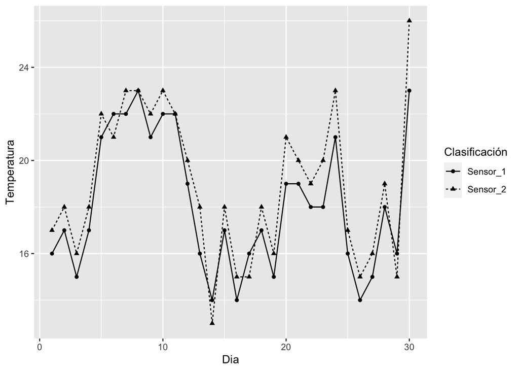

Temperatura de dos sensores en una piscina de cultivo

```r
tem <- read_excel("temperatura.xlsx", sheet = 2)
ggplot(tem, aes(x=Dia, y=Temperatura, group=Clasificación)) +
  geom_line(aes(linetype=Clasificación))+
  geom_point(aes(shape=Clasificación))
```

1. Escriba su hipótesis nula y alternativa para este experimento.

```r
# H0 : La temperatura de ambos sensores NO es distinta.
# HA : La temperatura de ambos sensores es distinta.
```

2. Importe la hoja 1 set de datos **temperatura** usando la función *read_excel()* de la librería *readxl*. No olvide usar el argumento *Sheet=1*. Explore el set de datos usando las funciones *summary()* y *str()*.

```r
temperatura <- read_excel("temperatura.xlsx", sheet = 1)
summary(temperatura)
```

```
##       Dia           Sensor_1       Senson_2
##  Min.   : 1.00   Min.   :14.0   Min.   :13.00
##  1st Qu.: 8.25   1st Qu.:16.0   1st Qu.:16.25
##  Median :15.50   Median :17.5   Median :18.50
##  Mean   :15.50   Mean   :18.1   Mean   :18.97
##  3rd Qu.:22.75   3rd Qu.:21.0   3rd Qu.:21.75
##  Max.   :30.00   Max.   :23.0   Max.   :26.00
```

```r
str(temperatura)
```

```
## tibble [30 × 3] (S3: tbl_df/tbl/data.frame)
##  $ Dia     : num [1:30] 1 2 3 4 5 6 7 8 9 10 ...
##  $ Sensor_1: num [1:30] 16 17 15 17 21 22 22 23 21 22 ...
##  $ Senson_2: num [1:30] 17 18 16 18 22 21 23 23 22 23 ...
```

3. Ponga a prueba su hipótesis usando el test de wilcoxon usando la función **wilcox.test()**, no olvide seleccionar en el argumento *alternative=""* para indicar que hipótesis evaluará *“two.sided”*, *“less”*, *“greater”*.

```r
# no es necesario indicar muestras pareadas pues estamos haciendo la resta en la función.
wilcox.test(temperatura$Sensor_1 - temperatura$Senson_2, alternative = "two.sided")
```

```
##
##  Wilcoxon signed rank test with continuity correction
##
## data:  temperatura$Sensor_1 - temperatura$Senson_2
## V = 48, p-value = 0.0001594
## alternative hypothesis: true location is not equal to 0
```

3. Interprete sus resultados.

### **Ejercicio 6.** Comparación de múltiples muestras independientes.

En el siguiente experimento se desea evaluar el efecto de 3 diferentes medios de cultivo (NUTRI: Nutrilake; GUILL Guillard; MONO: Monoammonuim Phosphate) sobre el tiempo medio generacional de la microalga *Chaetoceros muelleri* como alimento para la producción de copépodos.

Tabla. Tiempo generacional de Chaetoceros muelleri alimentada con 3 medios diferentes de cultivo.

| NUTRI | GUILL | MONO |
| --- | --- | --- |
| 27 | 25 | 24 |
| 26 | 26 | 23 |
| 27 | 28 | 22 |
| 28 | 24 | 22 |

1. Escriba su hipótesis nula y alternativa para este experimento.

```r
# H0 : El Tiempo generacional de Chaetoceros muelleri no es diferente entre 3 medios cultivo: NUTRI, GUILL, MONO.
# HA :  El Tiempo generacional de Chaetoceros muelleri es diferente entre 3 medios cultivo: NUTRI, GUILL, MONO.
```

```r
g1 <- c(27, 26, 27, 28) # NUTRI
g2 <- c(25, 26, 28, 24) # GUILL
g3 <- c(24, 23, 22, 22) # MONO



kruskal.test(list(g1, g2, g3))
```

```
##
##  Kruskal-Wallis rank sum test
##
## data:  list(g1, g2, g3)
## Kruskal-Wallis chi-squared = 7.7607, df = 2, p-value = 0.02064
```

3. Interprete sus resultados.